# Lab 5

David Murillo

Octuber 12, 2022

## Marbled salamander dispersal data

### Background

The data for this exercise represent the dispersal of juvenile marbled salamanders from their natal ponds to neighboring ponds.

The data were derived from a long-term study of marbled salamanders in western Massachusetts in which a cluster of 14 vernal pools were monitored continuously between 1999-2004. All juveniles were marked upon leaving their natal ponds. Subsequent recaptures at non-natal ponds were used to determine dispersal rates between ponds for first-time breeders (ftb).

In the data set provided, the dispersal rates have been standardized to account for several factors, including the propensity for dispersal from each pond and the available distances between ponds owing to the unique configuration of ponds. The data set includes three variables:

1. `dist.class` = distance class, based on 100 m intervals;
2. `disp.rate.ftb` = standardized dispersal rate for first-time breeders, which can be interpreted as a relative dispersal probability.
3. `disp.rate.eb` = standardized dispersal rate for experienced breeders, which can be interpreted as a relative dispersal probability

# Question

## Exponential Function

Instructions:

Complete the template R code (from the walkthrough above) to build your exponential function. Make sure you read the note about parameter `b` in the lab instructions. To gain visual intuition, try using `curve()` to plot your function.

- Try out different values of the two parameters as well as plotting over different ranges of x-values.
- Try plotting two or more curves with slightly different parameter values on the same plot
- You may need to try out different ranges of x-values in your plot windows to make sure you are focusing on the interesting parts of the curves.
- Try different line colors, widths, and textures.
- **Q1 (2 pts.): Show the R code you used to create `exp_fun()`**

**Answer:**

```r
exp_fun = function(x,a,b){
  return(a*exp(-b*x))
  }
```

- **Q2 (4 pts.): In your lab report, include a single figure containing **four** negative exponential curves with the following parameter values and line colors/textures:**
- curve 1: a = 1.9, b = 0.1, line color = black, line texture = solid
- curve 2: a = 1.9, b = 0.3, line color = black, line texture = dotted
- curve 3: a = 1.2, b = 0.2, line color = red, line texture = solid
- curve 4: a = 1.2, b = 0.4, line color = red, line texture = dotted
- Hint: check out the from, to, ylim, and add arguments for curve(). Setting appropriate x- and y-limits in your plot will help you see all four curves.

**Answer:**

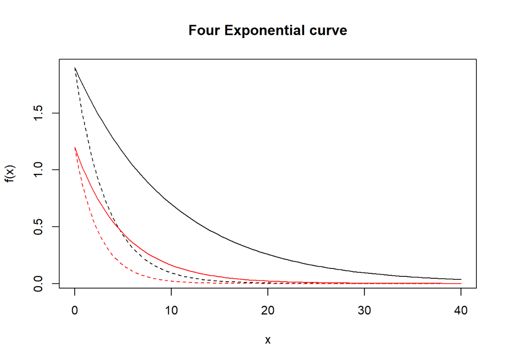

- **Q3 (2 pts.): Observe how the curves vary as you change the two parameters’ values. Qualitatively describe what happens to the curve as you vary parameter `a`**

**Answer: Because `a` is the y-intercept, when we change `a` the y-intercept will change**

## Ricker Functions

Instructions:

1. To gain visual intuition, try using `curve()` to plot the Ricker function.
- Try out different values of the two parameters as well as plotting over different ranges of x-values.
- Try plotting two or more curves with slightly different parameter values on the same plot
- You may need to try out different ranges of x-values in your plot windows to make sure you are focusing on the interesting parts of the curves.
- Try different line colors, widths, and textures.
- **Q5 (6 pts.): In your lab report, include a single plot containing 6 Ricker curves with these parameter values:**

*curve 1: a = 25, b = 0.2, line color = black, line texture = solid

*curve 2: a = 20, b = 0.2, line color = black, line texture = dotted

*curve 3: a = 10, b = 0.2, line color = black, line texture = dotted

*curve 4: a = 75, b = 0.3, line color = red, line texture = solid

*curve 5: a = 50, b = 0.3, line color = red, line texture = dotted

*curve 6: a = 40, b = 0.3, line color = red, line texture = dotted

**Answer**

[figure not shown]

- **Q6 (2 pts.): Observe how the curves vary as you change the two parameters’ values. Qualitatively describe what happens to the curve as you vary parameter `a`**

- **Q7 (2 pts.): Observe how the curves vary as you change the two parameters’ values. Qualitatively describe what happens to the curve as you vary parameter `b`**

**Answer: When the values of `b` is small, the “bell” will be high, when `b` is higher the high of the “bell” will be small**

## Salamander Models

Using the scatterplot of the salamander dispersal data for first time breeders, visually fit:

- a linear model
- an exponential model
- a Ricker model
- **Q8 (2 pts.): Linear Model. Provide the values of the slope, x1, and y1 parameters you chose. Briefly describe how you chose the values.**

**Answer: `x1= 500`, `y1= 0.4`, `slope = -0.0003`, I selected x1 and y1 using the plot, I look for one point and select the x and y values of that point, for the slope, the scatterplot look have negative relationship, and I try with diferent number to get the more adecuate for the model.**

- **Q9 (2 pts.): In your lab report, include a scatterplot of the salamander data with your fitted linear model.**

**Answer:**

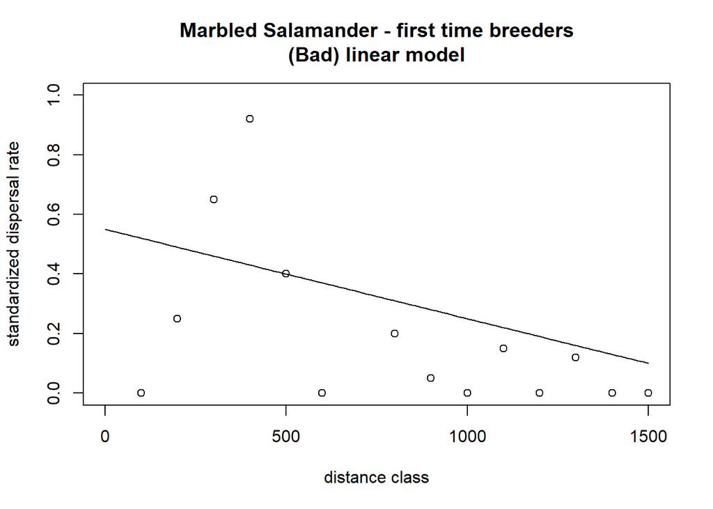

- **Q10 (2 pts.): Exponential Model. Provide the values of the a and b. Briefly describe how you chose the values.**

**Answer: `a= 1`, and `b = 0.009`, I try many times with different values of `a` and `b` to get an “adecuate fix”**

- **Q11 (2 pts.): In your lab report, include a scatterplot of the salamander data with your fitted exponential model.**

**Answer:**

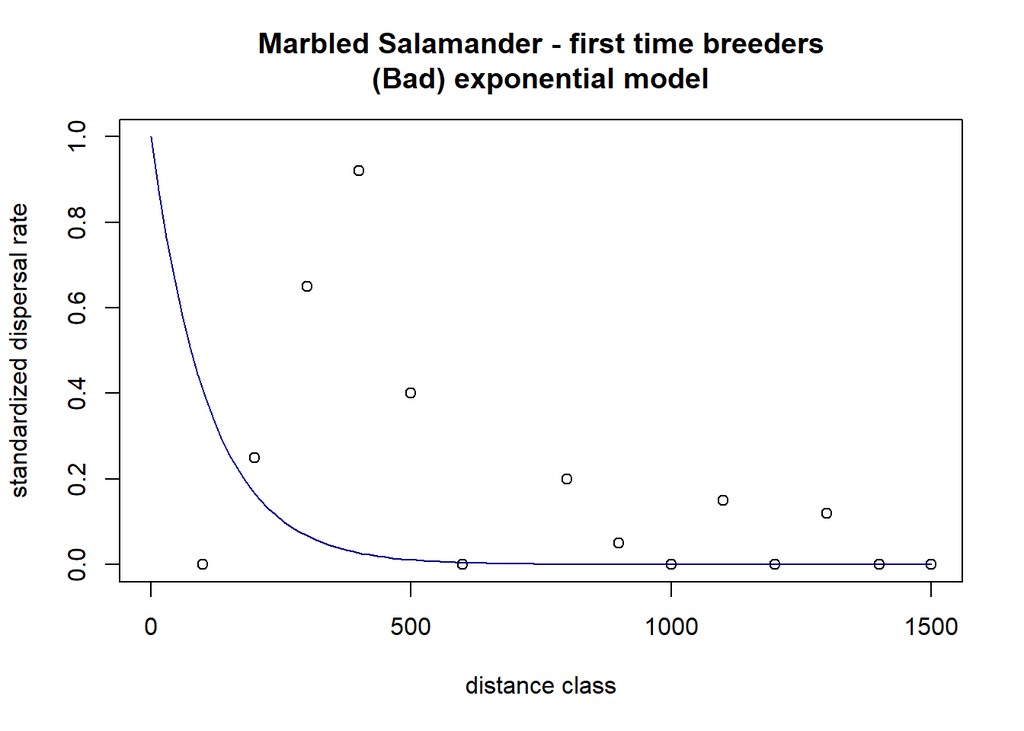

- **Q12 (2 pts.): Ricker Model Provide the values of the a and b. Briefly describe how you chose the values.**

**Answer: `a= 0.019`, and `b= 0.01`, these was the most difficult to found, I try a lot times with diffent values of `a` and `b` to get a lineal with “good fix”**

- **Q13 (2 pts.): In your lab report, include a scatterplot of the salamander data with your fitted ricker model.**

**Answer:**

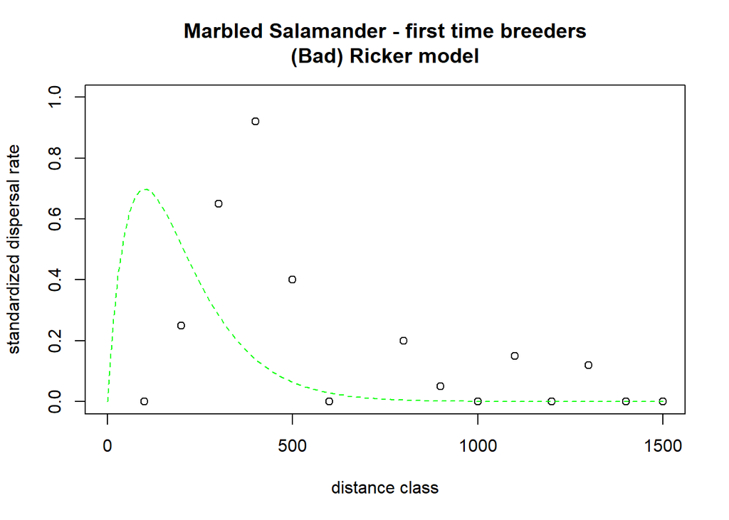

## Salamander Model Residuals

Calculate the residuals for your three fitted models and store them in a data.frame

- The columns containing the residuals should have the following names:
- “resids_linear”
- “resids_exp”
- “resids_ricker”
- **Q14 (4 pts.): Show the R code you used to create your data frame of model residuals.**

```r
Exp = dat_dispersal$disp.rate.ftb - exp_fun(dat_dispersal$dist.class, a= 1, b = 0.009)

Linear = dat_dispersal$disp.rate.ftb - line_point_slope(dat_dispersal$dist.class, x1= 500, y1= 0.4, slope= -0.0003)

Ricker = dat_dispersal$disp.rate.ftb - ricker_fun(dat_dispersal$dist.class, a= 0.019, b= 0.01)

Residuals <- data.frame(Exp, Linear, Ricker)

head(Residuals)
```

```
##            Exp Linear      Ricker
## 1 -0.406569660  -0.52 -0.69897094
## 2  0.084701112  -0.24 -0.26427408
## 3  0.582794487   0.19  0.36621371
## 4  0.892676278   0.49  0.78080114
## 5  0.388891003   0.00  0.33598950
## 6 -0.004516581  -0.37 -0.02825777
```

- **Q15 (3 pts.): In your lab report, include histograms of the residuals for each of your three models. You may create a single figure with three panels, or include three separate figures.**

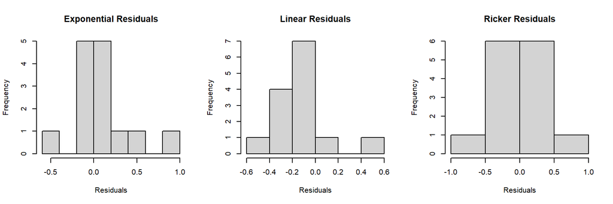